# CarbonTempo — Il suono delle emissioni

27/11/2026

## L’idea

**Domanda:** si può *ascoltare* la responsabilità storica delle emissioni di CO₂?

- Partiamo da un dataset reale (**Our World in Data – CO₂ Data**)
- Lo traduciamo in **parametri sonori**: altezza, volume, durata/riverbero, carattere timbrico
- Costruiamo un **sampler interattivo** in cui ogni pad è un continente in un anno chiave e ogni loop può essere **inciso su un vinile 12”** guidato dai dati

Data art: i numeri non restano solo su un asse cartesiano, ma diventano ritmo, peso e persistenza sonora.

## I dati e la pulizia

- **Our World in Data – CO₂ dataset**: 56.269 righe × 79 colonne, dal 1750 al 2025
- Variabili chiave: `population`, `co2`, `co2_per_capita`, `cumulative_co2`, `coal_co2`, `oil_co2`, `gas_co2`
- Pulizia in `tidyverse`:
  - paesi veri separati tramite `iso_code` (223 entità, 220 con CO₂ nel 2025; esclusi Kosovo e trasporti internazionali)
  - valori `NA` dei combustibili sostituiti con `0` **solo** quando `co2` è noto
  - tabella separata `data_continents` (`World` + 6 continenti) per evitare doppi conteggi

## Responsabilità storica cumulativa (1750–2025)

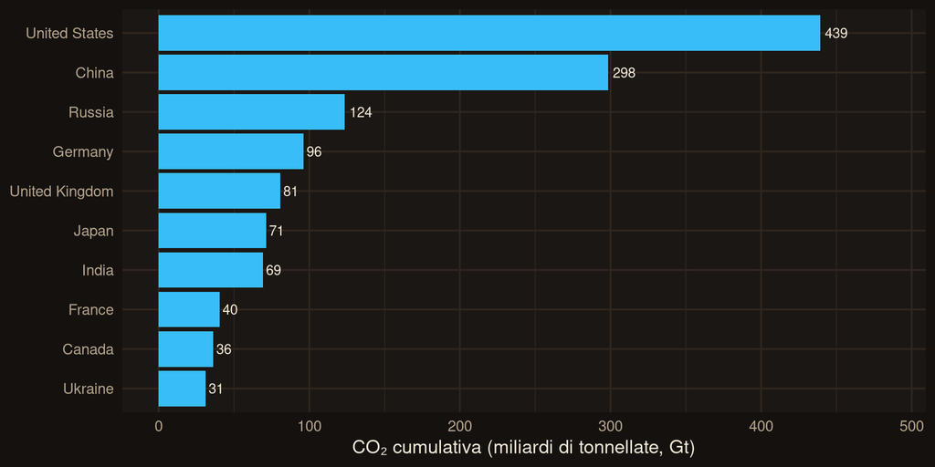

Nel 2025 la Cina guida le emissioni annuali (12.417 Mt), ma sul piano cumulativo gli USA restano primi (439 Gt).

## Popolazione vs CO₂ pro capite (2025)

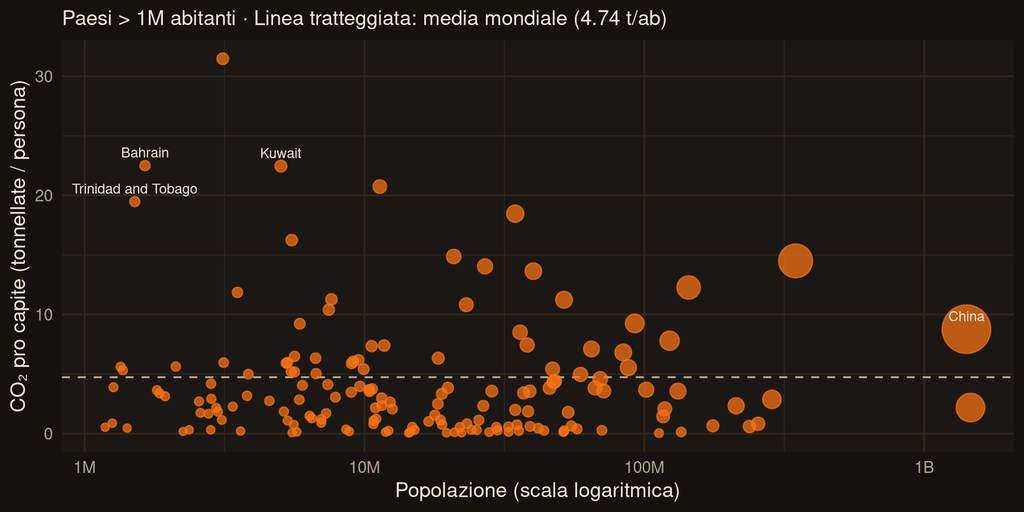

## Continenti e mix di combustibili

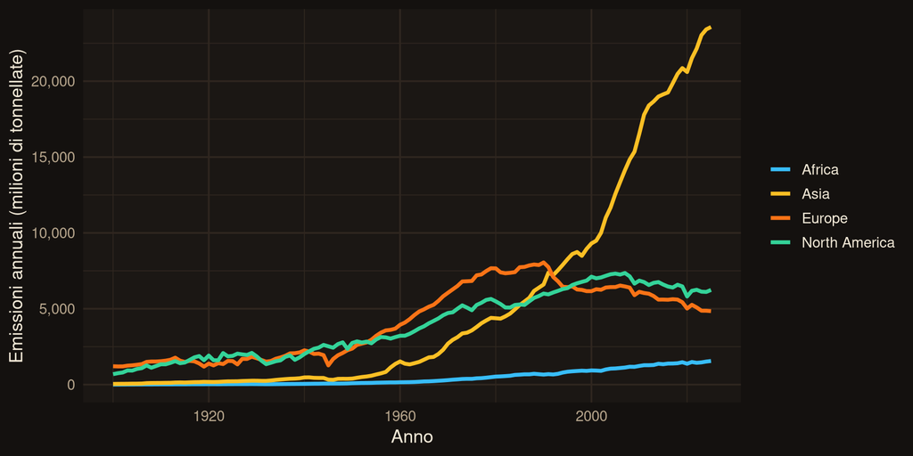

Dal 2000 l’Asia accelera fino a 23.572 Mt (2025). Nel frattempo il mix fossile mondiale somma carbone (40,3%), petrolio (32,9%) e gas (20,7%).

## Dal dato al suono: la mappatura

| Dato OWID | Parametro sonoro | Significato |
| --- | --- | --- |
| `co2_per_capita` | **Altezza** (`freq_hz_log`) | Più emissioni per persona → nota più acuta |
| `co2` (annuale) | **Volume** (`gain_norm`) | Radice quadrata del totale → peso sonoro leggibile |
| `cumulative_co2` | **Durata / Riverbero** (`decay_sec`) | La CO₂ persiste per secoli → coda sonora che resta |
| `coal / oil / gas_share` | **Carattere timbrico** | Le quote dei 3 combustibili modellano filtro e armoniche |

Quattro anni (**1900, 1950, 1990, 2025**) × quattro continenti = **16 pad** in `sampler_data.json`.

## Le formule e la scala percettiva

```r
pc_norm     <- co2_per_capita / max(co2_per_capita, na.rm = TRUE)
freq_hz_log <- round(65 * (585 / 65)^pc_norm, 1)
gain_norm   <- round(0.2 + 0.8 * (sqrt(co2) / sqrt(max(co2, na.rm = TRUE))), 3)
decay_sec   <- round(0.25 + 2.2 * (cumulative_co2 / max(cumulative_co2, na.rm = TRUE)), 2)
```

- **Perché `freq_hz_log`:** l’orecchio percepisce l’altezza in semitoni/ottave; questa formula cresce esponenzialmente in Hz ed è quindi **lineare in semitoni** (~2,7 semitoni per ogni `+1 t/persona`)
- È l’equivalente sonoro di un asse lineare: lascia evidenti le differenze assolute tra continenti
- La radice quadrata su `gain_norm` evita che i giganti emissivi azzerino l’Africa del 1900

## Come evolve l’altezza percettiva (`freq_hz_log`)

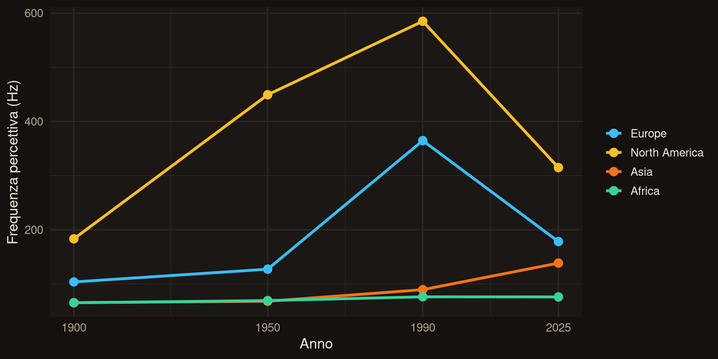

## Un continente, uno strumento

Per suonare insieme come una vera band, ogni colonna del sampler pilota uno **strumento sintetizzato** (intercambiabile dal menu) con panning stereo geografico:

| Continente | Freq. min (Hz) | Freq. max (Hz) | Strumento default | Pan Stereo |
| --- | --- | --- | --- | --- |
| Europe | 103.7 | 364.6 | Basso Analog (Europe) | Sinistra (-22%) |
| North America | 183.3 | 585.0 | Synth / Rhodes (N. America) | Sinistra (-55%) |
| Asia | 65.5 | 138.5 | Kick / Sub 808 (Asia) | Destra (+55%) |
| Africa | 65.2 | 76.2 | Snare / Perc + Hat (Africa) | Destra (+22%) |

Colonne disposte da Ovest a Est (o per ruolo ritmico): il bilanciamento stereo fa percepire lo spostamento geografico.

## Scelte audio: fedeltà e ascoltabilità

- **Scala musicale opzionale (`SCALA: DO MINORE` / `HZ GREZZI`):** in modalità musicale i pad vengono agganciati alla scala di Do minore con progressioni armoniche su 2 battute e accordi a 3 voci; con un clic si può tornare agli Hz grezzi puri
- **Riverbero al posto della confusione:** la coda lunga di `cumulative_co2` alimenta un riverbero stereo (`ConvolverNode`) + delay sincronizzato ai BPM, lasciando netti i transienti di kick e basso
- **Zero clipping (“fritto”):** saturazione calda normalizzata (`tanh`) e **Limiter master** (`DynamicsCompressorNode`) garantiscono un suono pulito anche nel 2025 e 2050

## Il sampler e l’incisione del vinile

- **16 pad live** (mouse/touch/tastiera `1–V`) + **sequencer a 16 step** (1 battuta in sedicesimi con swing)
- **`PLAY STORIA (1900→2050)`:** attraversa automaticamente tutte le 5 epoche in sequenza
- **`INCIDI VINILE`:** registra un giro del loop e genera un **vinile 12” PNG** (solchi incisi dall’esterno verso l’interno, bagliore legato alla temperatura, etichetta con l’anello del mix carbone/petrolio/gas)

Apri il sampler locale (100% offline): sampler.html

## Cosa si ascolta nelle 5 epoche (Demo live)

| Epoca | BPM | Pattern e sonorità | Significato |
| --- | --- | --- | --- |
| **1900** | 86 BPM | Boom-bap essenziale, carbone al 95,7% | Spazio, pochi colpi puliti |
| **1950** | 100 BPM | Groove sincopato, entra il petrolio (26,1%) | L’industria prende ritmo |
| **1990** | 116 BPM | Breakbeat serrato, petrolio al 40,6% | Grande accelerazione globale |
| **2025** | 128 BPM | Elettronica densa + pad del 1990 in sottofondo | Il passato accumulato pesa sul presente |
| **2050** | 140 BPM | Climax teso, leggera scordatura (+2.5 °C) | Scenario proiettivo, saturazione |

## Limiti, onestà dei dati e domande finali

- **Trasparenza dei dati:** totali globali, pro capite, curva 1900–2025 e quote dei combustibili nel sampler arrivano dai **dati reali OWID**; esterni sono solo i riferimenti di anomalia termica (NASA GISTEMP / HadCRUT) e la proiezione narrativa **2050**
- **1. La data art rivela pattern nuovi?** Sì: i grafici congelano il tempo sullo spazio, mentre il suono rende percepibili **durata cumulativa, densità e saturazione simultanea**
- **2. L’emozione è comprensione legittima?** Sì, purché nasca da mappature trasparenti: trasforma numeri astratti (`38.995 Mt` nel 2025) in esperienza fisica, superando lo *psychic numbing*

## Grazie — Demo Live

**CarbonTempo: Il suono delle emissioni**

- Analisi riproducibile: `progetto.Rmd` → `progetto.html`
- Opera interattiva offline: `sampler.html` (alimentata da `sampler_data.json`)
- Dati: Our World in Data, *CO₂ and Greenhouse Gas Emissions*

Samuele Antonello 162640, Tommaso Trentin 167340, …